# Conditional treatment effects estimation with the HAL-based R-learner

## Overview

Average treatment effects summarize how a treatment works across an entire population. In many applications, however, the treatment effect varies with a person’s baseline characteristics. The conditional average treatment effect (CATE) describes that heterogeneity.

In this tutorial, we provide an example of estimating the CATE with the **R-learner**. Here, highly adaptive lasso (HAL) basis functions provide a flexible representation of the covariates, and `glmnet` performs the Lasso fits.

By the end of this tutorial, you will be able to:

- construct a zero-order HAL design matrix;
- estimate the treatment propensity and marginal outcome regression;
- derive the weighted pseudo-outcome form of the R-loss;
- fit an R-learner with cross-validated Lasso regression; and
- evaluate the CATE.

## 1. Setup

We first load the packages we need for this tutorial. We will use `hal9001` to enumerate and evaluate HAL basis functions, `glmnet` for cross-validated Lasso regression, `origami` for folds, and `plotly` for interactive surfaces.

```r
library(hal9001)
library(glmnet)
library(furrr)
library(plotly)
library(origami)
library(dplyr)
library(tidyr)
library(ggplot2)
```

If needed, install the packages before proceeding the tutorial.

```r
install.packages(c(
  "hal9001", "glmnet", "furrr", "plotly", "origami",
  "dplyr", "tidyr", "ggplot2"
))
```

## 2. Data-generating process and target parameter

We observe $O=(W,A,Y)$, where $W=(W_1,W_2,W_3)$ contains baseline covariates, $A\in\{0,1\}$ is treatment, and $Y$ is a continuous outcome. The covariates are independently generated on a grid from $-1$ to $1$. Specifically, $W_j=\operatorname{round}(U_j,1)$, $U_j\sim\operatorname{Uniform}(-1,1)$, for $j=1,2,3.$

Treatment follows $A\mid W \sim \operatorname{Bernoulli}\{e_0(W)\}$ with $e_0(W)=\operatorname{expit}(-0.25W_1+W_2).$

The outcome is $Y=-0.5+W_1+0.5W_2+0.3W_3+A\tau_0(W_1,W_2)+U_Y$ with $U_Y\sim N(0,1),$ and the true CATE being $\tau_0(W_1,W_2)=0.5W_1+\sin(2\pi W_2).$

The effect changes linearly with $W_1$ and periodically with $W_2$. Although $W_3$ predicts the outcome, it does not modify the treatment effect.

**NoteIdentification assumptions**

Interpreting the conditional contrast as a causal effect requires consistency, conditional exchangeability $(Y^0,Y^1)\perp A\mid W$, and positivity $0<P(A=1\mid W=w)<1$ in the covariate region of interest. These conditions hold by construction in the simulation.

### Simulate one data set

The helper file `sim_data.R` contains the complete data-generating process.

```r
source("sim_data.R")

set.seed(1234)
n <- 2000
data <- sim_data(n)
W <- data[, grep("W", colnames(data))]
A <- data$A
Y <- data$Y
```

Let’s inspect the structure and basic summaries first.

```r
dplyr::glimpse(data)
```

```
Rows: 2,000
Columns: 5
$ W1 <dbl> -0.7, 0.4, -0.1, 0.3, -0.1, 0.9, 0.8, 0.6, -0.9, 0.3, -0.7, -0.2, -…
$ W2 <dbl> -0.3, -0.4, 0.4, -0.5, 0.2, 0.1, 0.9, 0.8, 0.9, 0.7, -0.3, 0.4, -0.…
$ W3 <dbl> -0.7, -0.1, -0.6, 0.5, -0.2, 0.6, 0.9, 0.7, 0.5, -0.5, 0.7, -0.3, -…
$ A  <int> 0, 0, 0, 1, 1, 0, 1, 1, 1, 1, 1, 0, 1, 0, 1, 1, 1, 1, 0, 1, 1, 0, 1…
$ Y  <dbl> -2.76706575, -0.05257076, 0.50444118, -2.49569770, 0.77018121, 1.13…
```

```r
data.frame(
  sample_size = nrow(data),
  treatment_prevalence = mean(A),
  outcome_mean = mean(Y),
  outcome_sd = sd(Y)
)
```

```
  sample_size treatment_prevalence outcome_mean outcome_sd
1        2000               0.4755   -0.5381055    1.31629
```

The following exploratory plot shows the observed outcome against $W_2$ by treatment group.

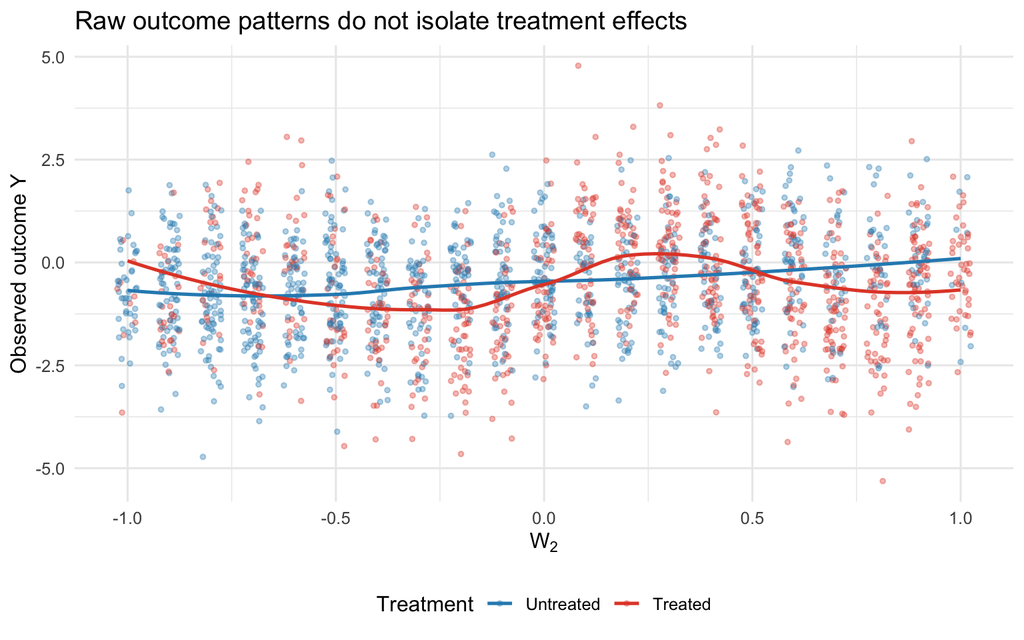

Figure 1: Observed outcomes across W2 by treatment status. Horizontal jitter separates the discrete W2 values.

```r
ggplot(data, aes(x = W2, y = Y, color = factor(A))) +
  geom_jitter(width = 0.025, height = 0, alpha = 0.35, size = 1) +
  geom_smooth(
    aes(group = factor(A)),
    method = "loess",
    se = FALSE,
    linewidth = 0.9
  ) +
  scale_color_manual(
    values = c("0" = "#2b8cbe", "1" = "#e34a33"),
    labels = c("0" = "Untreated", "1" = "Treated")
  ) +
  labs(
    x = expression(W[2]),
    y = "Observed outcome Y",
    color = "Treatment",
    title = "Raw outcome patterns do not isolate treatment effects"
  ) +
  theme_minimal(base_size = 12) +
  theme(legend.position = "bottom")
```

## 3. Create cross-validation folds

All three primary Lasso fits use the same five-fold split.

```r
# make folds
folds <- make_folds(n = n, V = 5)
foldid <- folds2foldvec(folds)
```

Check that every observation belongs to one fold and that fold sizes are reasonably balanced.

```r
fold_counts <- as.data.frame(table(foldid))
names(fold_counts) <- c("fold", "observations")
fold_counts
```

```
  fold observations
1    1          400
2    2          400
3    3          400
4    4          400
5    5          400
```

```r
stopifnot(length(foldid) == n, !anyNA(foldid))
```

**ImportantCross-validation is not cross-fitting**

Here, `cv.glmnet()` uses held-out folds to choose each Lasso penalty, but the final nuisance models are refit on the full sample and their fitted values are predicted on that same sample. A fully cross-fitted R-learner would instead use out-of-fold nuisance predictions for every observation. For pedagogical purposes, we go with a simpler implementation.

## 4. Construct the HAL basis

The first HAL basis represents functions of all three covariates. With `smoothness_orders = 0L`, the basis consists of indicator-type tensor-product functions. `max_degree = 2L` restricts covariate interactions up to two-way.

```r
basis_list <- enumerate_basis(x = W,
                              max_degree = 2L,
                              smoothness_orders = 0L)
phi_W <- make_design_matrix(X = as.matrix(W),
                            blist = basis_list)
```

Each row of `phi_W` corresponds to an observation. Each column is a candidate HAL basis function that `glmnet` may retain or shrink to zero.

```r
data.frame(
  observations = nrow(phi_W),
  candidate_basis_functions = ncol(phi_W),
  maximum_interaction_degree = 2L,
  smoothness_order = 0L
)
```

```
  observations candidate_basis_functions maximum_interaction_degree
1         2000                      1357                          2
  smoothness_order
1                0
```

## 5. Estimate the treatment propensity

Define $e_0(W)=E_0(A\mid W)=P_0(A=1\mid W).$

We estimate $e_0$ with binomial Lasso regression on the HAL basis.

```r
# estimate E(A|W)
g_fit <- cv.glmnet(x = phi_W,
                   y = A,
                   family = "binomial",
                   alpha = 1,
                   foldid = foldid)
g1W <- as.numeric(predict(g_fit, newx = phi_W, s = "lambda.min", type = "response"))
```

`g1W` is the fitted probability of treatment for each observation.

The simulated sample has comfortable empirical overlap.

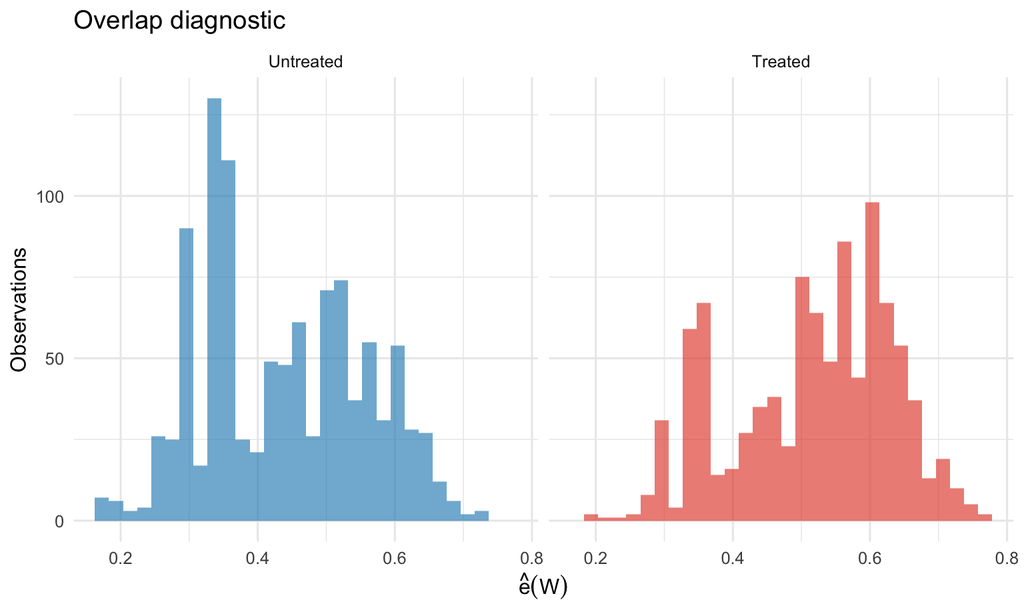

Figure 2: Distribution of fitted treatment probabilities within the observed treatment groups.

```r
data.frame(
  propensity = g1W,
  treatment = factor(A, labels = c("Untreated", "Treated"))
) |>
  ggplot(aes(x = propensity, fill = treatment)) +
  geom_histogram(bins = 30, alpha = 0.65, position = "identity") +
  facet_wrap(vars(treatment), nrow = 1) +
  scale_fill_manual(values = c("Untreated" = "#2b8cbe", "Treated" = "#e34a33")) +
  labs(
    x = expression(hat(e)(W)),
    y = "Observations",
    fill = NULL,
    title = "Overlap diagnostic"
  ) +
  theme_minimal(base_size = 12) +
  theme(legend.position = "none")
```

## 6. Estimate the marginal outcome regression

The second nuisance function is $m_0(W)=E_0(Y\mid W).$

This is not the treatment-specific outcome regression $E(Y\mid A,W)$. It is the outcome mean after averaging over the observed treatment mechanism. Under this simulation, $m_0(W)=-0.5+W_1+0.5W_2+0.3W_3+e_0(W)\tau_0(W_1,W_2).$

We use Gaussian Lasso regression on the same HAL design matrix.

```r
# estimate E(Y|W)
theta_fit <- cv.glmnet(x = phi_W,
                       y = Y,
                       family = "gaussian",
                       alpha = 1,
                       foldid = foldid)
theta <- as.numeric(predict(theta_fit, newx = phi_W, s = "lambda.min", type = "response"))
```

## 7. Derive and fit the R-loss

The Robinson decomposition motivates the R-learner: $Y-m_0(W)=\{A-e_0(W)\}\tau_0(W)+\varepsilon,$ where the remaining error is conditionally mean zero under the partially linear treatment-effect model. Replacing the nuisance functions with estimates leads to the empirical R-loss

$$\mathcal L_R(\tau)=\sum_{i=1}^n\bigg\{Y_i-\hat m(W_i)-(A_i-\hat e(W_i))\tau(W_i)\bigg\}^2.$$

### Weighted pseudo-outcome form

For observations with $A_i\neq\hat e(W_i)$, define $\widetilde Y_i=(Y_i-\hat m(W_i))/(A_i-\hat e(W_i))$ and $\omega_i=\{A_i-\hat e(W_i)\}^2.$

Then

$$\omega_i(\widetilde Y_i-\tau(W_i))^2=\bigg\{Y_i-\hat m(W_i)-\{A_i-\hat e(W_i)\}\tau(W_i)\bigg\}^2.$$

Thus, a weighted regression of the pseudo-outcome on $W$ minimizes the R-loss.

```r
# R-loss
pseudo_outcome <- (Y-theta)/(A-g1W)
pseudo_weights <- (A-g1W)^2
```

We now fit a Gaussian Lasso of the pseudo-outcome on the full HAL basis using the R-loss weights.

```r
r_lrnr_fit <- cv.glmnet(x = phi_W,
                        y = pseudo_outcome,
                        weights = pseudo_weights,
                        family = "gaussian",
                        alpha = 1,
                        foldid = foldid)
cate <- as.numeric(predict(r_lrnr_fit, newx = phi_W, s = "lambda.min", type = "response"))
```

### Assess fitted CATE values at the observed covariates

In a simulation, the true effect is available at every observed $W$.

```r
true_cate_observed <- 0.5 * data$W1 + sin(2 * pi * data$W2)

observed_cate_error <- data.frame(
  MAE = mean(abs(cate - true_cate_observed)),
  RMSE = sqrt(mean((cate - true_cate_observed)^2)),
  correlation = cor(cate, true_cate_observed)
)

summary(cate)
```

```
     Min.   1st Qu.    Median      Mean   3rd Qu.      Max.
-1.402539 -0.512010 -0.060810 -0.002658  0.584456  2.010944
```

```r
observed_cate_error
```

```
        MAE     RMSE correlation
1 0.2735193 0.344946   0.8881704
```

## 8. Summarize the CATE over effect modifiers

The primary R-learner used $W_1$, $W_2$, and $W_3$. For visualization, we could fit a second HAL that summarizes `cate` as a function of $W_1$ and $W_2$ only.

```r
# CATE on W1, W2
basis_list_W1W2 <- enumerate_basis(x = data[, c("W1", "W2")],
                                   max_degree = 2L,
                                   smoothness_orders = 0L)
phi_W1W2 <- make_design_matrix(X = as.matrix(data[, c("W1", "W2")]),
                               blist = basis_list_W1W2)
cate_W1W2_fit <- cv.glmnet(x = phi_W1W2,
                           y = cate,
                           family = "gaussian",
                           alpha = 1,
                           foldid = foldid)
```

## 9. Evaluate the estimated CATE on a grid

We evaluate both the estimated and true treatment effects on all combinations of 21 values of $W_1$ and 21 values of $W_2$. This produces a $21\times21=441$ point grid over the support used by the data generator.

```r
W1_vals <- seq(-1, 1, 0.1)
W2_vals <- seq(-1, 1, 0.1)
grid <- expand.grid(W1 = W1_vals,
                    W2 = W2_vals)
grid_hal_design <- make_design_matrix(X = as.matrix(grid),
                                      blist = basis_list_W1W2)
grid$pred_cate <- as.numeric(predict(cate_W1W2_fit, newx = grid_hal_design,
                                     s = "lambda.min", type = "response"))
grid$true_cate <- sim_data(n, grid = grid[, c("W1", "W2")])
```

### Compare one-dimensional slices

Holding $W_1$ fixed makes the sinusoidal dependence on $W_2$ easy to see.

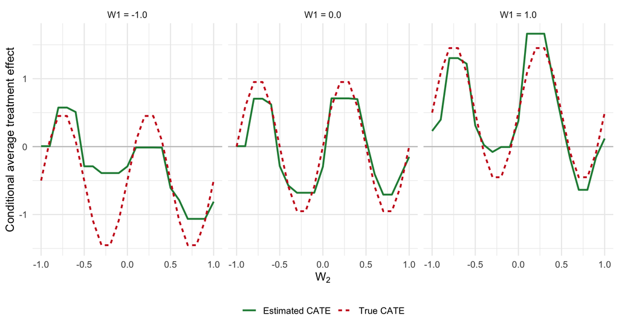

Figure 3: Estimated and true CATE curves over W2 at three fixed values of W1.

```r
slice_W1_vals <- c(-1, 0, 1)

grid |>
  filter(W1 %in% slice_W1_vals) |>
  select(W1, W2, pred_cate, true_cate) |>
  pivot_longer(
    cols = c(pred_cate, true_cate),
    names_to = "curve",
    values_to = "CATE"
  ) |>
  mutate(
    curve = recode(
      curve,
      pred_cate = "Estimated CATE",
      true_cate = "True CATE"
    ),
    W1_slice = factor(
      sprintf("W1 = %.1f", W1),
      levels = sprintf("W1 = %.1f", slice_W1_vals)
    )
  ) |>
  ggplot(aes(x = W2, y = CATE, color = curve, linetype = curve)) +
  geom_hline(yintercept = 0, color = "grey75", linewidth = 0.5) +
  geom_line(linewidth = 0.9) +
  facet_wrap(vars(W1_slice), nrow = 1) +
  scale_color_manual(values = c(
    "Estimated CATE" = "#238b45",
    "True CATE" = "#cb181d"
  )) +
  labs(
    x = expression(W[2]),
    y = "Conditional average treatment effect",
    color = NULL,
    linetype = NULL
  ) +
  theme_minimal(base_size = 12) +
  theme(legend.position = "bottom")
```

The true curves have the same sinusoidal shape and are vertically separated by $0.5W_1$.

## 10. Build interactive CATE surfaces

```r
pred_cate_mat <- matrix(grid$pred_cate,
                        nrow = length(W2_vals),
                        ncol = length(W1_vals),
                        byrow = TRUE)
true_cate_mat <- matrix(grid$true_cate,
                        nrow = length(W2_vals),
                        ncol = length(W1_vals),
                        byrow = TRUE)

stopifnot(
  identical(dim(pred_cate_mat), c(length(W2_vals), length(W1_vals))),
  identical(dim(true_cate_mat), c(length(W2_vals), length(W1_vals)))
)
```

```r
plt_pred <- plot_ly(x = W1_vals, y = W2_vals, z = pred_cate_mat,
                    colorscale = "Greens") %>%
  add_surface() %>%
  layout(title = list(text = "Estimated CATE",
                      font = list(size = 18, color = "black"),
                      yref = "container",
                      y = 0.98),
         scene = list(xaxis = list(title = "W1", titlefont = list(size = 14)),
                      yaxis = list(title = "W2", titlefont = list(size = 14)),
                      zaxis = list(title = "CATE", titlefont = list(size = 14), range = c(-1.5, 1.5)),
                      camera = list(eye = list(x = -1.5, y = 1.5, z = 0.8))),
         legend = list(x = 0.8, y = 1, font = list(size = 12)))

plt_true <- plot_ly(x = W1_vals, y = W2_vals, z = true_cate_mat,
                    colorscale = "Reds") %>%
  add_surface() %>%
  layout(title = list(text = "True CATE",
                      font = list(size = 18, color = "black"),
                      yref = "container",
                      y = 0.98),
         scene = list(xaxis = list(title = "W1", titlefont = list(size = 14)),
                      yaxis = list(title = "W2", titlefont = list(size = 14)),
                      zaxis = list(title = "CATE", titlefont = list(size = 14), range = c(-1.5, 1.5)),
                      camera = list(eye = list(x = -1.5, y = 1.5, z = 0.8))),
         legend = list(x = 0.8, y = 1, font = list(size = 12)))
```

### Estimated CATE surface

Drag to rotate, scroll to zoom, and hover to read individual values.

```r
plt_pred
```

[interactive chart not shown]

Figure 4: R-learner estimate of the CATE surface over W1 and W2.

### True CATE surface

The true surface combines the plane $0.5W_1$ with the wave $\sin(2\pi W_2)$.

```r
plt_true
```

[interactive chart not shown]

Figure 5: True CATE surface over W1 and W2.